# R Notebook

Step 1 obtain initial metadata from each project

search “PRJEBXXXX” in website:https://www.ncbi.nlm.nih.gov/Traces/study/ , then click Metadata item in the “Select” table and download it. You will obtain a table named “SraRunTable.csv”, which contains the metadata information

```r
library(dplyr)
setwd("D:/oral_project/PRJNA782768")
initial_meta<-read.csv("SraRunTable.csv",header = T)
initial_meta1<-read.csv("SraRunTable1.csv",header = T)
meta<-rbind(initial_meta,initial_meta1)
meta<-subset(meta,Organism!="gut metagenome")
nrow(subset(meta,grepl("HT",Sample.Name)))
```

```
## [1] 34
```

```r
head(meta)
```

|  | Run | Assay.Type | AvgSpotLen | Bases | BioProject | BioSample | BioSampleModel | Bytes | Center.Name | Collection_Date | Consent | DATASTORE.filetype | DATASTORE.provider | DATASTORE.region | Experiment | geo_loc_name_country | geo_loc_name_country_continent | geo_loc_name | HOST | Instrument | isolation_source | lat_lon | Library.Name | LibraryLayout | LibrarySelection | LibrarySource | Organism | Platform | ReleaseDate | … |
| --- | --- | --- | --- | --- | --- | --- | --- | --- | --- | --- | --- | --- | --- | --- | --- | --- | --- | --- | --- | --- | --- | --- | --- | --- | --- | --- | --- | --- | --- | --- |
| 11 | SRR17012673 | AMPLICON | 493 | 44859056 | PRJNA782768 | SAMN23394734 | Metagenome or environmental | 14879583 | SCHOOL OF BASIC MEDICINE | 2021-01-05 | public | fastq,run.zq,sra | gs,ncbi,s3 | gs.us-east1,ncbi.public,s3.us-east-1 | SRX13202881 | China | Asia | China:Shanghai | missing | Illumina MiSeq | missing | 31.19 N 121.60 E | T11a | PAIRED | PCR | METAGENOMIC | oral metagenome | ILLUMINA | 2022-03-19T00:00:00Z | … |
| 12 | SRR17012674 | AMPLICON | 494 | 38840750 | PRJNA782768 | SAMN23394725 | Metagenome or environmental | 13064180 | SCHOOL OF BASIC MEDICINE | 2021-01-05 | public | fastq,run.zq,sra | gs,ncbi,s3 | gs.us-east1,ncbi.public,s3.us-east-1 | SRX13202880 | China | Asia | China:Shanghai | missing | Illumina MiSeq | missing | 31.19 N 121.60 E | T02a | PAIRED | PCR | METAGENOMIC | oral metagenome | ILLUMINA | 2022-03-19T00:00:00Z | … |
| 13 | SRR17012675 | AMPLICON | 495 | 38367945 | PRJNA782768 | SAMN23394724 | Metagenome or environmental | 12895958 | SCHOOL OF BASIC MEDICINE | 2021-01-05 | public | fastq,run.zq,sra | gs,ncbi,s3 | gs.us-east1,ncbi.public,s3.us-east-1 | SRX13202879 | China | Asia | China:Shanghai | missing | Illumina MiSeq | missing | 31.19 N 121.60 E | T01a | PAIRED | PCR | METAGENOMIC | oral metagenome | ILLUMINA | 2022-03-19T00:00:00Z | … |
| 14 | SRR17012676 | AMPLICON | 492 | 34512816 | PRJNA782768 | SAMN23394783 | Metagenome or environmental | 11630135 | SCHOOL OF BASIC MEDICINE | 2021-01-06 | public | fastq,run.zq,sra | gs,ncbi,s3 | gs.us-east1,ncbi.public,s3.us-east-1 | SRX13202877 | China | Asia | China:Shanghai | missing | Illumina MiSeq | missing | 31.19 N 121.60 E | Tb20 | PAIRED | PCR | METAGENOMIC | oral metagenome | ILLUMINA | 2022-03-19T00:00:00Z | … |
| 15 | SRR17012677 | AMPLICON | 493 | 35535440 | PRJNA782768 | SAMN23394782 | Metagenome or environmental | 11872474 | SCHOOL OF BASIC MEDICINE | 2021-01-06 | public | fastq,run.zq,sra | gs,ncbi,s3 | gs.us-east1,ncbi.public,s3.us-east-1 | SRX13202876 | China | Asia | China:Shanghai | missing | Illumina MiSeq | missing | 31.19 N 121.60 E | Tb19 | PAIRED | PCR | METAGENOMIC | oral metagenome | ILLUMINA | 2022-03-19T00:00:00Z | … |
| 16 | SRR17012678 | AMPLICON | 494 | 31619458 | PRJNA782768 | SAMN23394781 | Metagenome or environmental | 10519269 | SCHOOL OF BASIC MEDICINE | 2021-01-06 | public | fastq,run.zq,sra | gs,ncbi,s3 | gs.us-east1,ncbi.public,s3.us-east-1 | SRX13202875 | China | Asia | China:Shanghai | missing | Illumina MiSeq | missing | 31.19 N 121.60 E | Tb18 | PAIRED | PCR | METAGENOMIC | oral metagenome | ILLUMINA | 2022-03-19T00:00:00Z | … |

Step 2 make a uniform metadata by selecting columns from the initial_meta dataframe

#每列格式说明

1、BioProject：Project ID like “PRJNA339212”

2、Run：sample id with a name such as “ERRXXXXXX” or “SRRXXXXXX”

3、sample_name： 数据提交时的样品编号，不是数据库分配的编号

4、Age

5、BMI

6、Sex：fill with “F”, “M”

7、PCR_primers such as: 515F-806R,514F-805R,341F-785R,8F-926R,515F-926R, this usually can be found in method section of a paper

8、Region such as V2,V4,V3-V4,V1-V5,V6-V8,V3-V5

9、Platform “such as: 454,Illumina MiSeq,Illumina HiSeq 2000,Illumina HiSeq,Illumi MiSeq,Illumina,Illumina HiSeq 2500,Illumina NovaSeq 6000,Illumina MiniSeq,Illumi HiSeq 2500,ILLUMINANextSeq2000”

10、Country：China,USA,Brazil

11、Site ：“saliva,tongue,oral mucosa,dental plaque,oral swab,tooth,subgingival plaque,tongue coating,oral wash,buccal mucosa,lower jaw mucosa,lower labial mucosa,upper jaw mucosa,Spain,oral cavity,hard palate swab,keratinized gingiva swab,palatine tonsils swab,tongue dorsum swab,supragingival plaque,gingival sulcus,periodontal pocket,carious material,Swab,Attached_Keratinized_gingiva,hard palate,tongue dorsum”

12、public_time ：数据第一次发布的时间（ReleaseDate） 格式：2015-10-15

13、title： paper title

14、 Disease_study fill with “YES” if the paper related to disease study,otherwise fill with “NO”

15、Status： if ”Disease_study“ is YES, fill with the exact disease information such as “PD”, “IBD”, “Dental_Caries”

```r
### create a uniform dataframe
uniform_meta <- data.frame(
  BioProject = meta$BioProject,
  Run = meta$Run,
  sample_name = meta$Sample.Name,
  Age = NA,
  BMI = NA,
  Sex=NA,
  Region = "V3-V4",
  Platform = meta$Instrument,
  Country = meta$geo_loc_name_country,
  Site = meta$Organism,
  public_time = meta$ReleaseDate,
  stringsAsFactors = FALSE
)
```

```r
library(ggplot2)
```

Step 3 find the other needed information by read the paper, and fill the left columns

```r
# 查阅对应文献，补齐其他列信息
uniform_meta$PCR_primers <- "338F-806R"
uniform_meta$title <- "Distribution characteristics of oral microbiota and its relationship with intestinal microbiota in patients with type 2 diabetes mellitus"
uniform_meta$Disease_study <- "YES"
##STatus列收集要特别注意，有些研究中同时有疾病样本和健康对照样本，疾病信息要对应到每个样本。
uniform_meta<-uniform_meta%>%
  mutate(Status=case_when(grepl("DT",sample_name)~"T2DM",grepl("HT|Tb",sample_name)~"HC"))
```

summrize

```r
print(length(unique(uniform_meta$Run)))
```

```
## [1] 298
```

```r
print(length(unique(uniform_meta$sample_name)))
```

```
## [1] 298
```

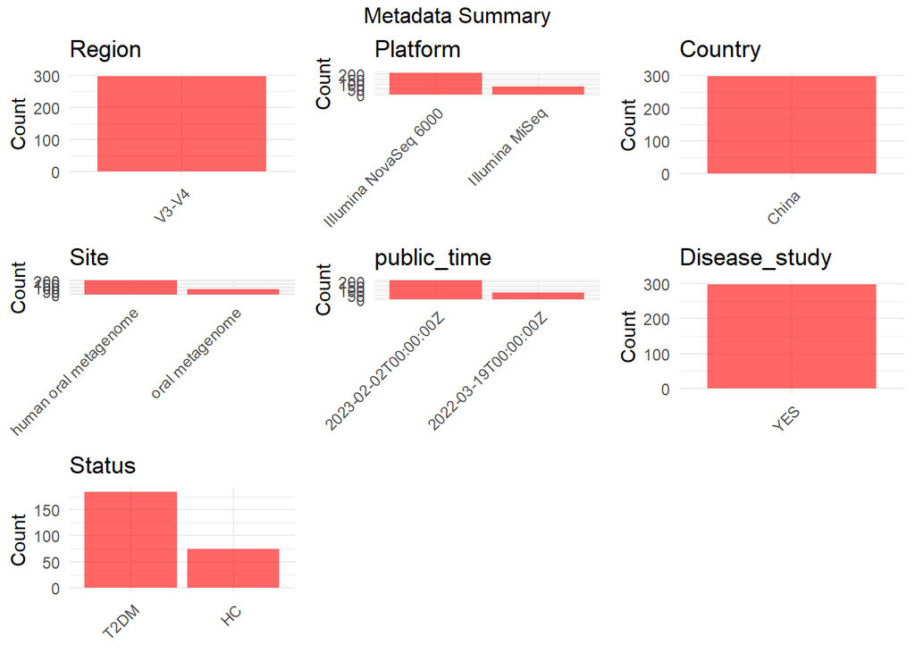

```r
##visualization
library(ggplot2)
library(gridExtra)
# 只选择需要绘制的列
plot_data <- uniform_meta %>%
  select(-BioProject, -Run, -sample_name, -title,-PCR_primers,-Age,-BMI,-Sex)

# 自动创建图形
create_simple_plots <- function(data) {
  plots <- list()

  for (col in colnames(data)) {
    if (is.numeric(data[[col]])) {
      # 数值变量：直方图
      p <- ggplot(data, aes(x = .data[[col]])) +
        geom_histogram(fill = "blue", alpha = 0.6, bins = 20) +
        labs(title = col) +
        theme_minimal()
    } else {
      # 分类变量：柱状图
      count_data <- as.data.frame(table(data[[col]]))
      p <- ggplot(count_data, aes(x = reorder(Var1, -Freq), y = Freq)) +
        geom_col(fill = "red", alpha = 0.6) +
        labs(title = col, x = NULL, y = "Count") +
        theme_minimal() +
        theme(axis.text.x = element_text(angle = 45, hjust = 1))
    }
    plots[[col]] <- p
  }

  return(plots)
}

# 生成图形并排列
plots <- create_simple_plots(plot_data)
grid.arrange(grobs = plots, ncol = 3, top = "Metadata Summary")
```

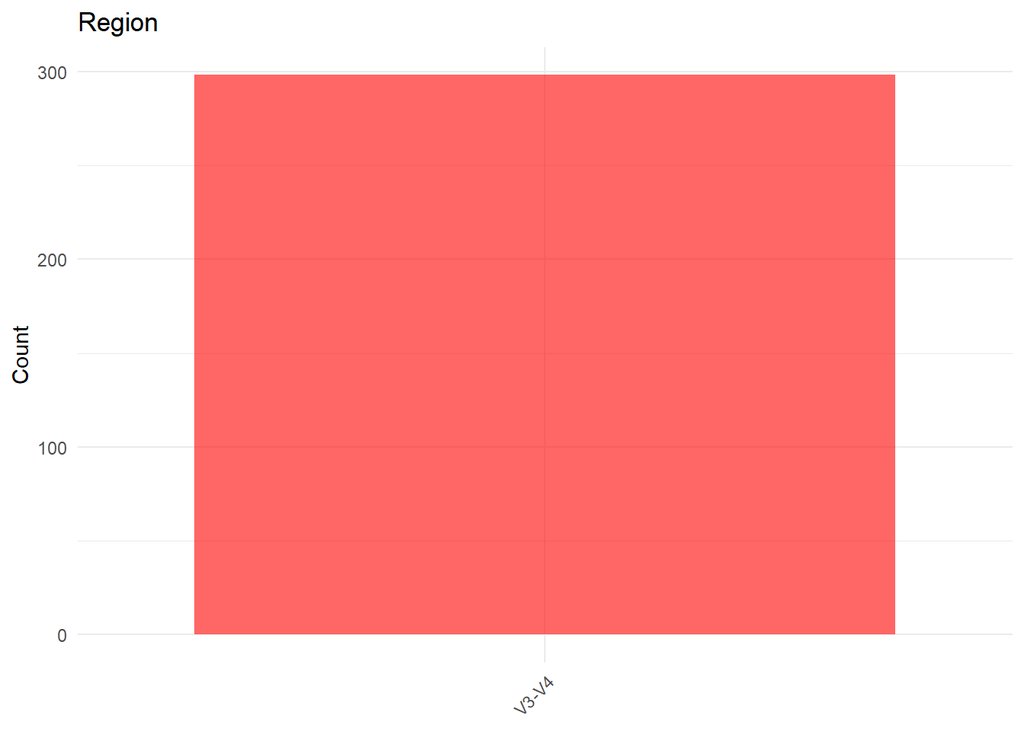

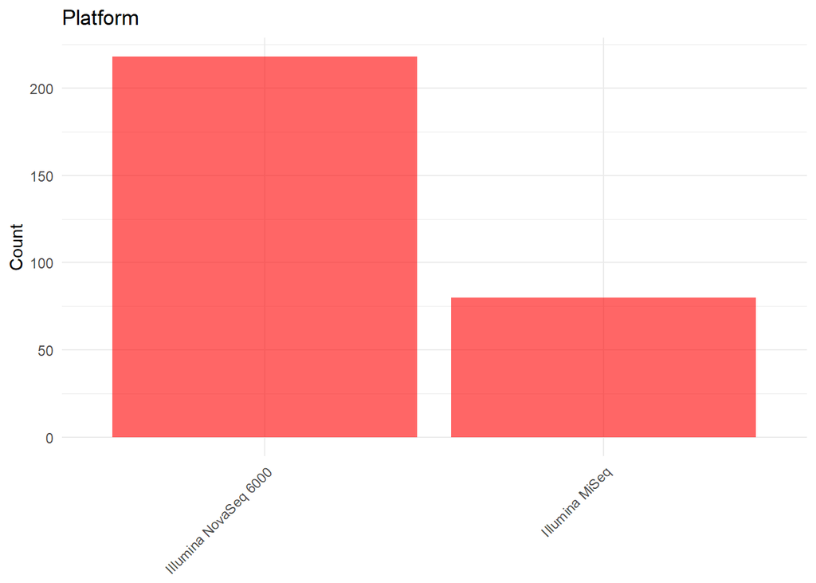

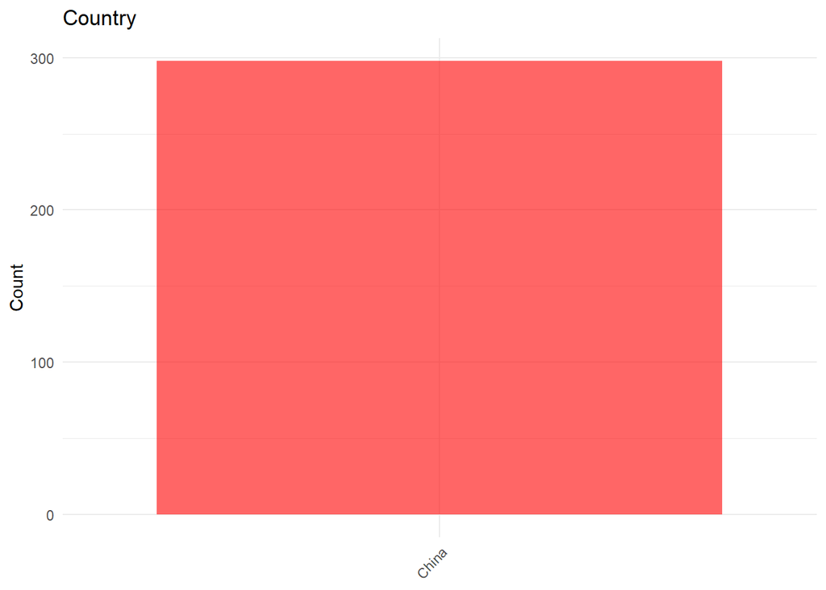

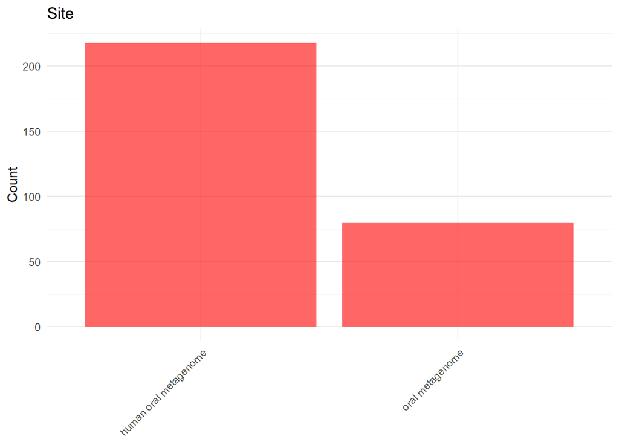

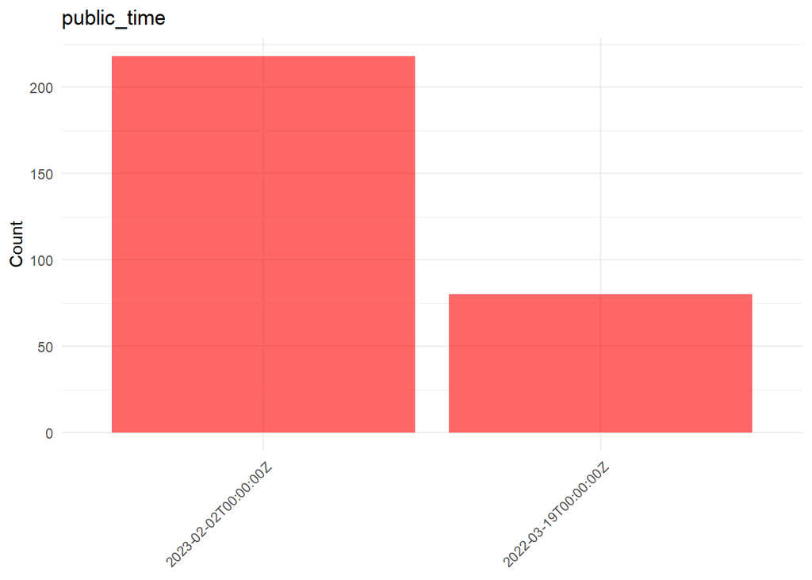

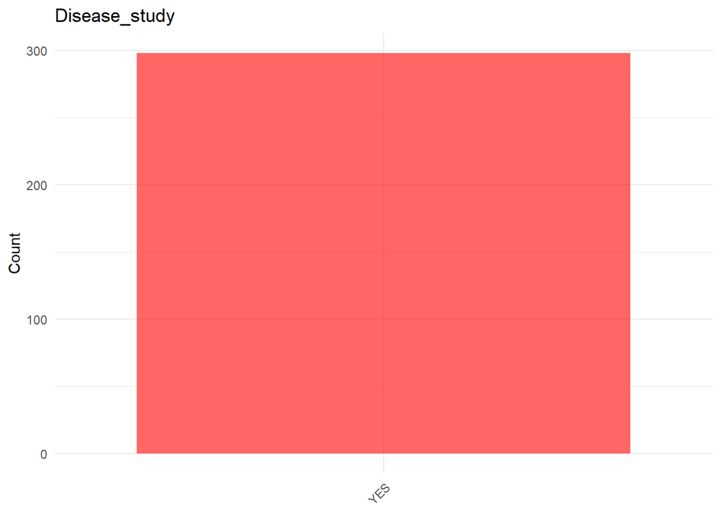

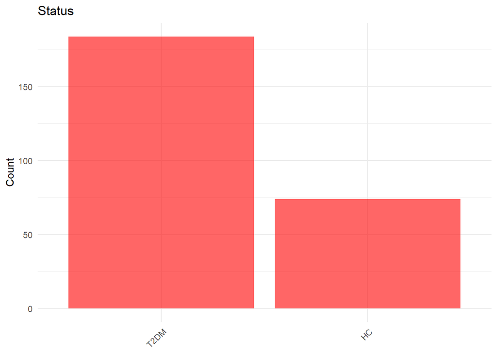

```r
print(plots)
```

```r
##uniform the column order
uniform_meta<-uniform_meta[,c("BioProject","Run","sample_name","Age","BMI","Sex","Region","Platform","Country","Site","public_time","PCR_primers","title","Disease_study","Status")]
write.csv(uniform_meta,file="uniform_meta.csv",quote = F)
```